# Introduction to Spark

```python
DATA_ROOT = "/content/drive/MyDrive/data/"
```

```python
!apt-get install openjdk-8-jdk-headless -qq > /dev/null
!wget -q https://archive.apache.org/dist/spark/spark-3.1.2/spark-3.1.2-bin-hadoop3.2.tgz
!tar -xvf spark-3.1.2-bin-hadoop3.2.tgz
!pip install -q findspark
import os
os.environ["JAVA_HOME"] = "/usr/lib/jvm/java-8-openjdk-amd64"
os.environ["SPARK_HOME"] = "/content/spark-3.1.2-bin-hadoop3.2"
import findspark
findspark.init()
from pyspark.sql import SparkSession

spark = SparkSession.builder.master("local[*]").getOrCreate()
```

[output not shown]

[output cut: 1456 more lines]

[output not shown]

```python
from google.colab import drive
drive.mount('/content/drive')
```

## Basic initialization

`SparkSession` is used to connect to the Spark Cluster.

```python
!pip install pandas==1.5.3
```

```python
from pyspark.sql import SparkSession
```

We will use Pandas to operate on the reduced data in the *driver program*.

```python
import pandas as pd
```

Numpy will be always useful.

```python
import numpy as np
```

Create a new session (or reuse an existing one).

```python
spark = SparkSession.builder.getOrCreate()
```

```python
spark
```

**SparkSession - in-memory**

**SparkContext**

[Spark UI](http://567691f8029b:4040)

**Version**

`v3.1.2`

**Master**

`local[*]`

**AppName**

`pyspark-shell`

We can see that the session is established.

## Creating Spark Data Frames from Pandas

We can list the tables in our Spark Session, currently empty.

```python
print(spark.catalog.listTables())
```

```
[]
```

We can create a Pandas `DataFrame` with random values.

```python
pd_temp = pd.DataFrame(np.random.random(100))
```

We can see on the plot that it is really random:

```python
import matplotlib
import matplotlib.pyplot as plt
matplotlib.style.use('ggplot')
```

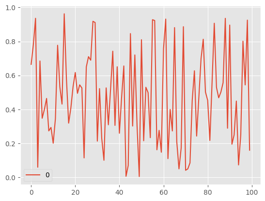

```python
pd_temp.plot()
```

Now we can convert it into Spark DataFrame:

```python
spark_temp = spark.createDataFrame(pd_temp)
```

`createOrReplaceTempView` creates (or replaces if that view name already exists) a lazily evaluated "view" that you can then use like a table in Spark SQL.

It does not persist to memory unless you cache (persist) the dataset that underpins the view.

```python
spark_temp.createOrReplaceTempView("temp")
```

The created view is `TEMPORARY` which means it is not persistent.

```python
print(spark.catalog.listTables())
```

```
[Table(name='temp', database=None, description=None, tableType='TEMPORARY', isTemporary=True)]
```

```python
spark_temp.show()
```

```
+-------------------+
|                  0|
+-------------------+
| 0.6654319427936718|
| 0.7802995519528932|
| 0.9362861601515028|
|0.06047940428551102|
|  0.685109934454958|
| 0.3485149712010184|
|0.39970752500926265|
| 0.4649997435225982|
| 0.2739860376518365|
| 0.2944635257917171|
| 0.2017144174035923|
| 0.3457729183242739|
| 0.7777308334899871|
| 0.5332876807264547|
| 0.4317366890249127|
| 0.9627688735653956|
| 0.5784685249670568|
| 0.3197971320835197|
|  0.408687993221462|
| 0.5341065453517381|
+-------------------+
only showing top 20 rows
```

We can now use transformations on this DataFrame. The transformations are translated (compiled) to RDD transformations.

```python
from pyspark.sql.functions import col, asc
```

```python
spark_temp.filter((col('0') > 0.9)).show()
```

```
+------------------+
|                 0|
+------------------+
|0.9362861601515028|
|0.9627688735653956|
|0.9185220578959663|
|0.9114702277476029|
|0.9280499217380909|
|0.9231286148593469|
|0.9317355624352033|
|0.9072092507838605|
|0.9360388908027262|
|0.9255782058547589|
+------------------+
```

## Creating Spark Data Frames from input files

```python
file_path = DATA_ROOT + "airports.csv"

# Read in the airports data
airports = spark.read.csv(file_path,header=False)

# Show the data
print(airports.show())
```

```
+---+--------------------+--------------+----------------+---+----+------------------+-------------------+----+---+----+--------------------+-------+-----------+
|_c0|                 _c1|           _c2|             _c3|_c4| _c5|               _c6|                _c7| _c8|_c9|_c10|                _c11|   _c12|       _c13|
+---+--------------------+--------------+----------------+---+----+------------------+-------------------+----+---+----+--------------------+-------+-----------+
|  1|      Goroka Airport|        Goroka|Papua New Guinea|GKA|AYGA|-6.081689834590001|      145.391998291|5282| 10|   U|Pacific/Port_Moresby|airport|OurAirports|
|  2|      Madang Airport|        Madang|Papua New Guinea|MAG|AYMD|    -5.20707988739|      145.789001465|  20| 10|   U|Pacific/Port_Moresby|airport|OurAirports|
|  3|Mount Hagen Kagam...|   Mount Hagen|Papua New Guinea|HGU|AYMH|-5.826789855957031| 144.29600524902344|5388| 10|   U|Pacific/Port_Moresby|airport|OurAirports|
|  4|      Nadzab Airport|        Nadzab|Papua New Guinea|LAE|AYNZ|         -6.569803|         146.725977| 239| 10|   U|Pacific/Port_Moresby|airport|OurAirports|
|  5|Port Moresby Jack...|  Port Moresby|Papua New Guinea|POM|AYPY|-9.443380355834961| 147.22000122070312| 146| 10|   U|Pacific/Port_Moresby|airport|OurAirports|
|  6|Wewak Internation...|         Wewak|Papua New Guinea|WWK|AYWK|    -3.58383011818|      143.669006348|  19| 10|   U|Pacific/Port_Moresby|airport|OurAirports|
|  7|  Narsarsuaq Airport|  Narssarssuaq|       Greenland|UAK|BGBW|     61.1604995728|     -45.4259986877| 112| -3|   E|     America/Godthab|airport|OurAirports|
|  8|Godthaab / Nuuk A...|      Godthaab|       Greenland|GOH|BGGH|       64.19090271|     -51.6781005859| 283| -3|   E|     America/Godthab|airport|OurAirports|
|  9|Kangerlussuaq Air...|   Sondrestrom|       Greenland|SFJ|BGSF|     67.0122218992|     -50.7116031647| 165| -3|   E|     America/Godthab|airport|OurAirports|
| 10|      Thule Air Base|         Thule|       Greenland|THU|BGTL|     76.5311965942|     -68.7032012939| 251| -4|   E|       America/Thule|airport|OurAirports|
| 11|    Akureyri Airport|      Akureyri|         Iceland|AEY|BIAR| 65.66000366210938| -18.07270050048828|   6|  0|   N|  Atlantic/Reykjavik|airport|OurAirports|
| 12| Egilsstaðir Airport|   Egilsstadir|         Iceland|EGS|BIEG|  65.2833023071289|-14.401399612426758|  76|  0|   N|  Atlantic/Reykjavik|airport|OurAirports|
| 13|Hornafjörður Airport|          Hofn|         Iceland|HFN|BIHN|         64.295601|           -15.2272|  24|  0|   N|  Atlantic/Reykjavik|airport|OurAirports|
| 14|     Húsavík Airport|       Husavik|         Iceland|HZK|BIHU|         65.952301|         -17.426001|  48|  0|   N|  Atlantic/Reykjavik|airport|OurAirports|
| 15|  Ísafjörður Airport|    Isafjordur|         Iceland|IFJ|BIIS| 66.05809783935547|-23.135299682617188|   8|  0|   N|  Atlantic/Reykjavik|airport|OurAirports|
| 16|Keflavik Internat...|      Keflavik|         Iceland|KEF|BIKF|   63.985000610352|   -22.605600357056| 171|  0|   N|  Atlantic/Reykjavik|airport|OurAirports|
| 17|Patreksfjörður Ai...|Patreksfjordur|         Iceland|PFJ|BIPA|         65.555801|            -23.965|  11|  0|   N|  Atlantic/Reykjavik|airport|OurAirports|
| 18|   Reykjavik Airport|     Reykjavik|         Iceland|RKV|BIRK|     64.1299972534|     -21.9405994415|  48|  0|   N|  Atlantic/Reykjavik|airport|OurAirports|
| 19|Siglufjörður Airport|  Siglufjordur|         Iceland|SIJ|BISI|         66.133301|           -18.9167|  10|  0|   N|  Atlantic/Reykjavik|airport|OurAirports|
| 20|Vestmannaeyjar Ai...|Vestmannaeyjar|         Iceland|VEY|BIVM| 63.42430114746094|-20.278900146484375| 326|  0|   N|  Atlantic/Reykjavik|airport|OurAirports|
+---+--------------------+--------------+----------------+---+----+------------------+-------------------+----+---+----+--------------------+-------+-----------+
only showing top 20 rows

None
```

It may be useful to convert them to Pandas for quick browsing.

**Warning!** This is not efficient for large datasets, as it requires performing actions on the dataset.

```python
airports.toPandas()
```

|  | _c0 | _c1 | _c2 | _c3 | _c4 | _c5 | _c6 | _c7 | _c8 | _c9 | _c10 | _c11 | _c12 | _c13 |
| --- | --- | --- | --- | --- | --- | --- | --- | --- | --- | --- | --- | --- | --- | --- |
| 0 | 1 | Goroka Airport | Goroka | Papua New Guinea | GKA | AYGA | -6.081689834590001 | 145.391998291 | 5282 | 10 | U | Pacific/Port_Moresby | airport | OurAirports |
| 1 | 2 | Madang Airport | Madang | Papua New Guinea | MAG | AYMD | -5.20707988739 | 145.789001465 | 20 | 10 | U | Pacific/Port_Moresby | airport | OurAirports |
| 2 | 3 | Mount Hagen Kagamuga Airport | Mount Hagen | Papua New Guinea | HGU | AYMH | -5.826789855957031 | 144.29600524902344 | 5388 | 10 | U | Pacific/Port_Moresby | airport | OurAirports |
| 3 | 4 | Nadzab Airport | Nadzab | Papua New Guinea | LAE | AYNZ | -6.569803 | 146.725977 | 239 | 10 | U | Pacific/Port_Moresby | airport | OurAirports |
| 4 | 5 | Port Moresby Jacksons International Airport | Port Moresby | Papua New Guinea | POM | AYPY | -9.443380355834961 | 147.22000122070312 | 146 | 10 | U | Pacific/Port_Moresby | airport | OurAirports |
| ... | ... | ... | ... | ... | ... | ... | ... | ... | ... | ... | ... | ... | ... | ... |
| 7179 | 12053 | Rugao Air Base | Rugao | China | RUG | ZSRG | 32.25788497924805 | 120.50165557861328 | 0 | \N | \N | \N | airport | OurAirports |
| 7180 | 12054 | Wuhu Air Base | Wuhu | China | WHU | ZSWU | 31.3906 | 118.408997 | 0 | \N | \N | \N | airport | OurAirports |
| 7181 | 12055 | Shanshan Airport | Shanshan | China | SXJ | ZWSS | 42.91170120239258 | 90.24749755859375 | 0 | \N | \N | \N | airport | OurAirports |
| 7182 | 12056 | Yingkou Lanqi Airport | Yingkou | China | YKH | ZYYK | 40.542524 | 122.3586 | 0 | \N | \N | \N | airport | OurAirports |
| 7183 | 12057 | Shenyang Dongta Airport | Shenyang | China | \N | ZYYY | 41.784400939941406 | 123.49600219726562 | 0 | \N | \N | \N | airport | OurAirports |

7184 rows × 14 columns

### Running SQL queries on dataframes

```python
airports.createOrReplaceTempView("airports")
```

```python
# Get the first 10 rows of flights
query = "FROM airports SELECT * LIMIT 10"

airports10 = spark.sql(query)

# Show the results
airports10.show()
```

```
+---+--------------------+------------+----------------+---+----+------------------+------------------+----+---+----+--------------------+-------+-----------+
|_c0|                 _c1|         _c2|             _c3|_c4| _c5|               _c6|               _c7| _c8|_c9|_c10|                _c11|   _c12|       _c13|
+---+--------------------+------------+----------------+---+----+------------------+------------------+----+---+----+--------------------+-------+-----------+
|  1|      Goroka Airport|      Goroka|Papua New Guinea|GKA|AYGA|-6.081689834590001|     145.391998291|5282| 10|   U|Pacific/Port_Moresby|airport|OurAirports|
|  2|      Madang Airport|      Madang|Papua New Guinea|MAG|AYMD|    -5.20707988739|     145.789001465|  20| 10|   U|Pacific/Port_Moresby|airport|OurAirports|
|  3|Mount Hagen Kagam...| Mount Hagen|Papua New Guinea|HGU|AYMH|-5.826789855957031|144.29600524902344|5388| 10|   U|Pacific/Port_Moresby|airport|OurAirports|
|  4|      Nadzab Airport|      Nadzab|Papua New Guinea|LAE|AYNZ|         -6.569803|        146.725977| 239| 10|   U|Pacific/Port_Moresby|airport|OurAirports|
|  5|Port Moresby Jack...|Port Moresby|Papua New Guinea|POM|AYPY|-9.443380355834961|147.22000122070312| 146| 10|   U|Pacific/Port_Moresby|airport|OurAirports|
|  6|Wewak Internation...|       Wewak|Papua New Guinea|WWK|AYWK|    -3.58383011818|     143.669006348|  19| 10|   U|Pacific/Port_Moresby|airport|OurAirports|
|  7|  Narsarsuaq Airport|Narssarssuaq|       Greenland|UAK|BGBW|     61.1604995728|    -45.4259986877| 112| -3|   E|     America/Godthab|airport|OurAirports|
|  8|Godthaab / Nuuk A...|    Godthaab|       Greenland|GOH|BGGH|       64.19090271|    -51.6781005859| 283| -3|   E|     America/Godthab|airport|OurAirports|
|  9|Kangerlussuaq Air...| Sondrestrom|       Greenland|SFJ|BGSF|     67.0122218992|    -50.7116031647| 165| -3|   E|     America/Godthab|airport|OurAirports|
| 10|      Thule Air Base|       Thule|       Greenland|THU|BGTL|     76.5311965942|    -68.7032012939| 251| -4|   E|       America/Thule|airport|OurAirports|
+---+--------------------+------------+----------------+---+----+------------------+------------------+----+---+----+--------------------+-------+-----------+
```

### More complex examples

Read data from CSV file:

- `inferSchema` - to detect which columns are numbers (not strigs!) - useful e.g. for sorting.
- `header` - to read the firs line as column names

```python
countries = spark.read.csv(DATA_ROOT+"countries of the world.csv",inferSchema=True,header=True)
```

```python
countries.toPandas()
```

|  | Country | Region | Population | Area (sq. mi.) | Pop. Density (per sq. mi.) | Coastline (coast/area ratio) | Net migration | Infant mortality (per 1000 births) | GDP ($ per capita) | Literacy (%) | Phones (per 1000) | Arable (%) | Crops (%) | Other (%) | Climate | Birthrate | Deathrate | Agriculture | Industry | Service |
| --- | --- | --- | --- | --- | --- | --- | --- | --- | --- | --- | --- | --- | --- | --- | --- | --- | --- | --- | --- | --- |
| 0 | Afghanistan | ASIA (EX. NEAR EAST) | 31056997 | 647500 | 48,0 | 0,00 | 23,06 | 163,07 | 700.0 | 36,0 | 3,2 | 12,13 | 0,22 | 87,65 | 1 | 46,6 | 20,34 | 0,38 | 0,24 | 0,38 |
| 1 | Albania | EASTERN EUROPE | 3581655 | 28748 | 124,6 | 1,26 | -4,93 | 21,52 | 4500.0 | 86,5 | 71,2 | 21,09 | 4,42 | 74,49 | 3 | 15,11 | 5,22 | 0,232 | 0,188 | 0,579 |
| 2 | Algeria | NORTHERN AFRICA | 32930091 | 2381740 | 13,8 | 0,04 | -0,39 | 31 | 6000.0 | 70,0 | 78,1 | 3,22 | 0,25 | 96,53 | 1 | 17,14 | 4,61 | 0,101 | 0,6 | 0,298 |
| 3 | American Samoa | OCEANIA | 57794 | 199 | 290,4 | 58,29 | -20,71 | 9,27 | 8000.0 | 97,0 | 259,5 | 10 | 15 | 75 | 2 | 22,46 | 3,27 | None | None | None |
| 4 | Andorra | WESTERN EUROPE | 71201 | 468 | 152,1 | 0,00 | 6,6 | 4,05 | 19000.0 | 100,0 | 497,2 | 2,22 | 0 | 97,78 | 3 | 8,71 | 6,25 | None | None | None |
| ... | ... | ... | ... | ... | ... | ... | ... | ... | ... | ... | ... | ... | ... | ... | ... | ... | ... | ... | ... | ... |
| 222 | West Bank | NEAR EAST | 2460492 | 5860 | 419,9 | 0,00 | 2,98 | 19,62 | 800.0 | None | 145,2 | 16,9 | 18,97 | 64,13 | 3 | 31,67 | 3,92 | 0,09 | 0,28 | 0,63 |
| 223 | Western Sahara | NORTHERN AFRICA | 273008 | 266000 | 1,0 | 0,42 | None | None | NaN | None | None | 0,02 | 0 | 99,98 | 1 | None | None | None | None | 0,4 |
| 224 | Yemen | NEAR EAST | 21456188 | 527970 | 40,6 | 0,36 | 0 | 61,5 | 800.0 | 50,2 | 37,2 | 2,78 | 0,24 | 96,98 | 1 | 42,89 | 8,3 | 0,135 | 0,472 | 0,393 |
| 225 | Zambia | SUB-SAHARAN AFRICA | 11502010 | 752614 | 15,3 | 0,00 | 0 | 88,29 | 800.0 | 80,6 | 8,2 | 7,08 | 0,03 | 92,9 | 2 | 41 | 19,93 | 0,22 | 0,29 | 0,489 |
| 226 | Zimbabwe | SUB-SAHARAN AFRICA | 12236805 | 390580 | 31,3 | 0,00 | 0 | 67,69 | 1900.0 | 90,7 | 26,8 | 8,32 | 0,34 | 91,34 | 2 | 28,01 | 21,84 | 0,179 | 0,243 | 0,579 |

227 rows × 20 columns

We can inspect the schema of the DataFrame.

```python
countries.printSchema()
```

```
root
 |-- Country: string (nullable = true)
 |-- Region: string (nullable = true)
 |-- Population: integer (nullable = true)
 |-- Area (sq. mi.): integer (nullable = true)
 |-- Pop. Density (per sq. mi.): string (nullable = true)
 |-- Coastline (coast/area ratio): string (nullable = true)
 |-- Net migration: string (nullable = true)
 |-- Infant mortality (per 1000 births): string (nullable = true)
 |-- GDP ($ per capita): integer (nullable = true)
 |-- Literacy (%): string (nullable = true)
 |-- Phones (per 1000): string (nullable = true)
 |-- Arable (%): string (nullable = true)
 |-- Crops (%): string (nullable = true)
 |-- Other (%): string (nullable = true)
 |-- Climate: string (nullable = true)
 |-- Birthrate: string (nullable = true)
 |-- Deathrate: string (nullable = true)
 |-- Agriculture: string (nullable = true)
 |-- Industry: string (nullable = true)
 |-- Service: string (nullable = true)
```

### Examples of SQL Queries

```python
countries.createOrReplaceTempView("countries")
```

```python
spark.sql("SELECT * FROM countries WHERE Region LIKE '%OCEANIA%'").toPandas()
```

|  | Country | Region | Population | Area (sq. mi.) | Pop. Density (per sq. mi.) | Coastline (coast/area ratio) | Net migration | Infant mortality (per 1000 births) | GDP ($ per capita) | Literacy (%) | Phones (per 1000) | Arable (%) | Crops (%) | Other (%) | Climate | Birthrate | Deathrate | Agriculture | Industry | Service |
| --- | --- | --- | --- | --- | --- | --- | --- | --- | --- | --- | --- | --- | --- | --- | --- | --- | --- | --- | --- | --- |
| 0 | American Samoa | OCEANIA | 57794 | 199 | 290,4 | 58,29 | -20,71 | 9,27 | 8000 | 97,0 | 259,5 | 10 | 15 | 75 | 2 | 22,46 | 3,27 | None | None | None |
| 1 | Australia | OCEANIA | 20264082 | 7686850 | 2,6 | 0,34 | 3,98 | 4,69 | 29000 | 100,0 | 565,5 | 6,55 | 0,04 | 93,41 | 1 | 12,14 | 7,51 | 0,038 | 0,262 | 0,7 |
| 2 | Cook Islands | OCEANIA | 21388 | 240 | 89,1 | 50,00 | None | None | 5000 | 95,0 | 289,9 | 17,39 | 13,04 | 69,57 | 2 | 21 | None | 0,151 | 0,096 | 0,753 |
| 3 | Fiji | OCEANIA | 905949 | 18270 | 49,6 | 6,18 | -3,14 | 12,62 | 5800 | 93,7 | 112,6 | 10,95 | 4,65 | 84,4 | 2 | 22,55 | 5,65 | 0,089 | 0,135 | 0,776 |
| 4 | French Polynesia | OCEANIA | 274578 | 4167 | 65,9 | 60,60 | 2,94 | 8,44 | 17500 | 98,0 | 194,5 | 0,82 | 5,46 | 93,72 | 2 | 16,68 | 4,69 | 0,031 | 0,19 | 0,769 |
| 5 | Guam | OCEANIA | 171019 | 541 | 316,1 | 23,20 | 0 | 6,94 | 21000 | 99,0 | 492,0 | 9,09 | 16,36 | 74,55 | 2 | 18,79 | 4,48 | None | None | None |
| 6 | Kiribati | OCEANIA | 105432 | 811 | 130,0 | 140,94 | 0 | 48,52 | 800 | None | 42,7 | 2,74 | 50,68 | 46,58 | 2 | 30,65 | 8,26 | 0,089 | 0,242 | 0,668 |
| 7 | Marshall Islands | OCEANIA | 60422 | 11854 | 5,1 | 3,12 | -6,04 | 29,45 | 1600 | 93,7 | 91,2 | 16,67 | 38,89 | 44,44 | 2 | 33,05 | 4,78 | 0,317 | 0,149 | 0,534 |
| 8 | Micronesia, Fed. St. | OCEANIA | 108004 | 702 | 153,9 | 870,66 | -20,99 | 30,21 | 2000 | 89,0 | 114,8 | 5,71 | 45,71 | 48,58 | 2 | 24,68 | 4,75 | 0,289 | 0,152 | 0,559 |
| 9 | Nauru | OCEANIA | 13287 | 21 | 632,7 | 142,86 | 0 | 9,95 | 5000 | None | 143,0 | 0 | 0 | 100 | 2 | 24,76 | 6,7 | None | None | None |
| 10 | New Caledonia | OCEANIA | 219246 | 19060 | 11,5 | 11,83 | 0 | 7,72 | 15000 | 91,0 | 252,2 | 0,38 | 0,33 | 99,29 | 2 | 18,11 | 5,69 | 0,15 | 0,088 | 0,762 |
| 11 | New Zealand | OCEANIA | 4076140 | 268680 | 15,2 | 5,63 | 4,05 | 5,85 | 21600 | 99,0 | 441,7 | 5,6 | 6,99 | 87,41 | 3 | 13,76 | 7,53 | 0,043 | 0,273 | 0,684 |
| 12 | N. Mariana Islands | OCEANIA | 82459 | 477 | 172,9 | 310,69 | 9,61 | 7,11 | 12500 | 97,0 | 254,7 | 13,04 | 4,35 | 82,61 | 2 | 19,43 | 2,29 | None | None | None |
| 13 | Palau | OCEANIA | 20579 | 458 | 44,9 | 331,66 | 2,85 | 14,84 | 9000 | 92,0 | 325,6 | 8,7 | 4,35 | 86,95 | 2 | 18,03 | 6,8 | 0,062 | 0,12 | 0,818 |
| 14 | Papua New Guinea | OCEANIA | 5670544 | 462840 | 12,3 | 1,11 | 0 | 51,45 | 2200 | 64,6 | 10,9 | 0,46 | 1,44 | 98,1 | 2 | 29,36 | 7,25 | 0,353 | 0,381 | 0,266 |
| 15 | Samoa | OCEANIA | 176908 | 2944 | 60,1 | 13,69 | -11,7 | 27,71 | 5600 | 99,7 | 75,2 | 21,2 | 24,38 | 54,42 | 2 | 16,43 | 6,62 | 0,114 | 0,584 | 0,302 |
| 16 | Solomon Islands | OCEANIA | 552438 | 28450 | 19,4 | 18,67 | 0 | 21,29 | 1700 | None | 13,4 | 0,64 | 2 | 97,36 | 2 | 30,01 | 3,92 | 0,42 | 0,11 | 0,47 |
| 17 | Tonga | OCEANIA | 114689 | 748 | 153,3 | 56,02 | 0 | 12,62 | 2200 | 98,5 | 97,7 | 23,61 | 43,06 | 33,33 | 2 | 25,37 | 5,28 | 0,23 | 0,27 | 0,5 |
| 18 | Tuvalu | OCEANIA | 11810 | 26 | 454,2 | 92,31 | 0 | 20,03 | 1100 | None | 59,3 | 0 | 0 | 100 | 2 | 22,18 | 7,11 | 0,166 | 0,272 | 0,562 |
| 19 | Vanuatu | OCEANIA | 208869 | 12200 | 17,1 | 20,72 | 0 | 55,16 | 2900 | 53,0 | 32,6 | 2,46 | 7,38 | 90,16 | 2 | 22,72 | 7,82 | 0,26 | 0,12 | 0,62 |
| 20 | Wallis and Futuna | OCEANIA | 16025 | 274 | 58,5 | 47,08 | None | None | 3700 | 50,0 | 118,6 | 5 | 25 | 70 | 2 | None | None | None | None | None |

### Queries using PySpark DSL

DSL = Domain Specific Language - API similar to natural or other language, implemented as library in another language.

List all the countries with the population > 38 million

```python
countries.filter((col("Population") > 38000000)).orderBy("Population").toPandas()
```

|  | Country | Region | Population | Area (sq. mi.) | Pop. Density (per sq. mi.) | Coastline (coast/area ratio) | Net migration | Infant mortality (per 1000 births) | GDP ($ per capita) | Literacy (%) | Phones (per 1000) | Arable (%) | Crops (%) | Other (%) | Climate | Birthrate | Deathrate | Agriculture | Industry | Service |
| --- | --- | --- | --- | --- | --- | --- | --- | --- | --- | --- | --- | --- | --- | --- | --- | --- | --- | --- | --- | --- |
| 0 | Poland | EASTERN EUROPE | 38536869 | 312685 | 123,3 | 0,16 | -0,49 | 8,51 | 11100 | 99,8 | 306,3 | 45,91 | 1,12 | 52,97 | 3 | 9,85 | 9,89 | 0,05 | 0,311 | 0,64 |
| 1 | Argentina | LATIN AMER. & CARIB | 39921833 | 2766890 | 14,4 | 0,18 | 0,61 | 15,18 | 11200 | 97,1 | 220,4 | 12,31 | 0,48 | 87,21 | 3 | 16,73 | 7,55 | 0,095 | 0,358 | 0,547 |
| 2 | Spain | WESTERN EUROPE | 40397842 | 504782 | 80,0 | 0,98 | 0,99 | 4,42 | 22000 | 97,9 | 453,5 | 26,07 | 9,87 | 64,06 | 3 | 10,06 | 9,72 | 0,04 | 0,295 | 0,665 |
| 3 | Sudan | SUB-SAHARAN AFRICA | 41236378 | 2505810 | 16,5 | 0,03 | -0,02 | 62,5 | 1900 | 61,1 | 16,3 | 6,83 | 0,18 | 92,99 | 2 | 34,53 | 8,97 | 0,387 | 0,203 | 0,41 |
| 4 | Colombia | LATIN AMER. & CARIB | 43593035 | 1138910 | 38,3 | 0,28 | -0,31 | 20,97 | 6300 | 92,5 | 176,2 | 2,42 | 1,67 | 95,91 | 2 | 20,48 | 5,58 | 0,125 | 0,342 | 0,533 |
| 5 | South Africa | SUB-SAHARAN AFRICA | 44187637 | 1219912 | 36,2 | 0,23 | -0,29 | 61,81 | 10700 | 86,4 | 107,0 | 12,08 | 0,79 | 87,13 | 1 | 18,2 | 22 | 0,025 | 0,303 | 0,671 |
| 6 | Ukraine | C.W. OF IND. STATES | 46710816 | 603700 | 77,4 | 0,46 | -0,39 | 20,34 | 5400 | 99,7 | 259,9 | 56,21 | 1,61 | 42,18 | 3 | 8,82 | 14,39 | 0,187 | 0,452 | 0,361 |
| 7 | Burma | ASIA (EX. NEAR EAST) | 47382633 | 678500 | 69,8 | 0,28 | -1,8 | 67,24 | 1800 | 85,3 | 10,1 | 15,19 | 0,97 | 83,84 | 2 | 17,91 | 9,83 | 0,564 | 0,082 | 0,353 |
| 8 | Korea, South | ASIA (EX. NEAR EAST) | 48846823 | 98480 | 496,0 | 2,45 | 0 | 7,05 | 17800 | 97,9 | 486,1 | 17,18 | 1,95 | 80,87 | 3 | 10 | 5,85 | 0,033 | 0,403 | 0,563 |
| 9 | Italy | WESTERN EUROPE | 58133509 | 301230 | 193,0 | 2,52 | 2,07 | 5,94 | 26700 | 98,6 | 430,9 | 27,79 | 9,53 | 62,68 | None | 8,72 | 10,4 | 0,021 | 0,291 | 0,688 |
| 10 | United Kingdom | WESTERN EUROPE | 60609153 | 244820 | 247,6 | 5,08 | 2,19 | 5,16 | 27700 | 99,0 | 543,5 | 23,46 | 0,21 | 76,33 | 3 | 10,71 | 10,13 | 0,005 | 0,237 | 0,758 |
| 11 | France | WESTERN EUROPE | 60876136 | 547030 | 111,3 | 0,63 | 0,66 | 4,26 | 27600 | 99,0 | 586,4 | 33,53 | 2,07 | 64,4 | 4 | 11,99 | 9,14 | 0,022 | 0,214 | 0,764 |
| 12 | Congo, Dem. Rep. | SUB-SAHARAN AFRICA | 62660551 | 2345410 | 26,7 | 0,00 | 0 | 94,69 | 700 | 65,5 | 0,2 | 2,96 | 0,52 | 96,52 | 2 | 43,69 | 13,27 | 0,55 | 0,11 | 0,34 |
| 13 | Thailand | ASIA (EX. NEAR EAST) | 64631595 | 514000 | 125,7 | 0,63 | 0 | 20,48 | 7400 | 92,6 | 108,9 | 29,36 | 6,46 | 64,18 | 2 | 13,87 | 7,04 | 0,099 | 0,441 | 0,46 |
| 14 | Iran | ASIA (EX. NEAR EAST) | 68688433 | 1648000 | 41,7 | 0,15 | -0,84 | 41,58 | 7000 | 79,4 | 276,4 | 8,72 | 1,39 | 89,89 | 1 | 17 | 5,55 | 0,116 | 0,424 | 0,46 |
| 15 | Turkey | NEAR EAST | 70413958 | 780580 | 90,2 | 0,92 | 0 | 41,04 | 6700 | 86,5 | 269,5 | 30,93 | 3,31 | 65,76 | 3 | 16,62 | 5,97 | 0,117 | 0,298 | 0,585 |
| 16 | Ethiopia | SUB-SAHARAN AFRICA | 74777981 | 1127127 | 66,3 | 0,00 | 0 | 95,32 | 700 | 42,7 | 8,2 | 10,71 | 0,75 | 88,54 | 2 | 37,98 | 14,86 | 0,475 | 0,099 | 0,426 |
| 17 | Egypt | NORTHERN AFRICA | 78887007 | 1001450 | 78,8 | 0,24 | -0,22 | 32,59 | 4000 | 57,7 | 131,8 | 2,87 | 0,48 | 96,65 | 1 | 22,94 | 5,23 | 0,149 | 0,357 | 0,493 |
| 18 | Germany | WESTERN EUROPE | 82422299 | 357021 | 230,9 | 0,67 | 2,18 | 4,16 | 27600 | 99,0 | 667,9 | 33,85 | 0,59 | 65,56 | 3 | 8,25 | 10,62 | 0,009 | 0,296 | 0,695 |
| 19 | Vietnam | ASIA (EX. NEAR EAST) | 84402966 | 329560 | 256,1 | 1,05 | -0,45 | 25,95 | 2500 | 90,3 | 187,7 | 19,97 | 5,95 | 74,08 | 2 | 16,86 | 6,22 | 0,209 | 0,41 | 0,381 |
| 20 | Philippines | ASIA (EX. NEAR EAST) | 89468677 | 300000 | 298,2 | 12,10 | -1,5 | 23,51 | 4600 | 92,6 | 38,4 | 18,95 | 16,77 | 64,28 | 2 | 24,89 | 5,41 | 0,144 | 0,326 | 0,53 |
| 21 | Mexico | LATIN AMER. & CARIB | 107449525 | 1972550 | 54,5 | 0,47 | -4,87 | 20,91 | 9000 | 92,2 | 181,6 | 12,99 | 1,31 | 85,7 | 1,5 | 20,69 | 4,74 | 0,038 | 0,259 | 0,702 |
| 22 | Japan | ASIA (EX. NEAR EAST) | 127463611 | 377835 | 337,4 | 7,87 | 0 | 3,26 | 28200 | 99,0 | 461,2 | 12,19 | 0,96 | 86,85 | 3 | 9,37 | 9,16 | 0,017 | 0,258 | 0,725 |
| 23 | Nigeria | SUB-SAHARAN AFRICA | 131859731 | 923768 | 142,7 | 0,09 | 0,26 | 98,8 | 900 | 68,0 | 9,3 | 31,29 | 2,96 | 65,75 | 1,5 | 40,43 | 16,94 | 0,269 | 0,487 | 0,244 |
| 24 | Russia | C.W. OF IND. STATES | 142893540 | 17075200 | 8,4 | 0,22 | 1,02 | 15,39 | 8900 | 99,6 | 280,6 | 7,33 | 0,11 | 92,56 | None | 9,95 | 14,65 | 0,054 | 0,371 | 0,575 |
| 25 | Bangladesh | ASIA (EX. NEAR EAST) | 147365352 | 144000 | 1023,4 | 0,40 | -0,71 | 62,6 | 1900 | 43,1 | 7,3 | 62,11 | 3,07 | 34,82 | 2 | 29,8 | 8,27 | 0,199 | 0,198 | 0,603 |
| 26 | Pakistan | ASIA (EX. NEAR EAST) | 165803560 | 803940 | 206,2 | 0,13 | -2,77 | 72,44 | 2100 | 45,7 | 31,8 | 27,87 | 0,87 | 71,26 | 1 | 29,74 | 8,23 | 0,216 | 0,251 | 0,533 |
| 27 | Brazil | LATIN AMER. & CARIB | 188078227 | 8511965 | 22,1 | 0,09 | -0,03 | 29,61 | 7600 | 86,4 | 225,3 | 6,96 | 0,9 | 92,15 | 2 | 16,56 | 6,17 | 0,084 | 0,4 | 0,516 |
| 28 | Indonesia | ASIA (EX. NEAR EAST) | 245452739 | 1919440 | 127,9 | 2,85 | 0 | 35,6 | 3200 | 87,9 | 52,0 | 11,32 | 7,23 | 81,45 | 2 | 20,34 | 6,25 | 0,134 | 0,458 | 0,408 |
| 29 | United States | NORTHERN AMERICA | 298444215 | 9631420 | 31,0 | 0,21 | 3,41 | 6,5 | 37800 | 97,0 | 898,0 | 19,13 | 0,22 | 80,65 | 3 | 14,14 | 8,26 | 0,01 | 0,204 | 0,787 |
| 30 | India | ASIA (EX. NEAR EAST) | 1095351995 | 3287590 | 333,2 | 0,21 | -0,07 | 56,29 | 2900 | 59,5 | 45,4 | 54,4 | 2,74 | 42,86 | 2,5 | 22,01 | 8,18 | 0,186 | 0,276 | 0,538 |
| 31 | China | ASIA (EX. NEAR EAST) | 1313973713 | 9596960 | 136,9 | 0,15 | -0,4 | 24,18 | 5000 | 90,9 | 266,7 | 15,4 | 1,25 | 83,35 | 1,5 | 13,25 | 6,97 | 0,125 | 0,473 | 0,403 |

Select all the countries from Europe

```python
countries.select("Country", "Population").where(col("Region").like("%EUROPE%")).show()
```

```
+--------------------+----------+
|             Country|Population|
+--------------------+----------+
|            Albania |   3581655|
|            Andorra |     71201|
|            Austria |   8192880|
|            Belgium |  10379067|
|Bosnia & Herzegov...|   4498976|
|           Bulgaria |   7385367|
|            Croatia |   4494749|
|     Czech Republic |  10235455|
|            Denmark |   5450661|
|      Faroe Islands |     47246|
|            Finland |   5231372|
|             France |  60876136|
|            Germany |  82422299|
|          Gibraltar |     27928|
|             Greece |  10688058|
|           Guernsey |     65409|
|            Hungary |   9981334|
|            Iceland |    299388|
|            Ireland |   4062235|
|        Isle of Man |     75441|
+--------------------+----------+
only showing top 20 rows
```

Conditions in `where` clause can contain logical expressions.

```python
countries.select("Country", "Population")\
.where((col("Region").like("%EUROPE%")) & (col("Population")> 10000000)).show()
```

```
+---------------+----------+
|        Country|Population|
+---------------+----------+
|       Belgium |  10379067|
|Czech Republic |  10235455|
|        France |  60876136|
|       Germany |  82422299|
|        Greece |  10688058|
|         Italy |  58133509|
|   Netherlands |  16491461|
|        Poland |  38536869|
|      Portugal |  10605870|
|       Romania |  22303552|
|         Spain |  40397842|
|United Kingdom |  60609153|
+---------------+----------+
```

### Aggregation

We can run aggregations with predefined functions (faster!):

```python
from pyspark.sql.functions import sum
```

```python
pd_countries = countries.select("Region", "Population").groupBy("Region").agg(sum("Population")).toPandas()
```

```python
pd_countries
```

|  | Region | sum(Population) |
| --- | --- | --- |
| 0 | BALTICS | 7184974 |
| 1 | C.W. OF IND. STATES | 280081548 |
| 2 | ASIA (EX. NEAR EAST) | 3687982236 |
| 3 | WESTERN EUROPE | 396339998 |
| 4 | NORTHERN AMERICA | 331672307 |
| 5 | NEAR EAST | 195068377 |
| 6 | EASTERN EUROPE | 119914717 |
| 7 | OCEANIA | 33131662 |
| 8 | SUB-SAHARAN AFRICA | 749437000 |
| 9 | NORTHERN AFRICA | 161407133 |
| 10 | LATIN AMER. & CARIB | 561824599 |

We can make the column name look better, by using `alias`:

```python
pd_countries = countries.select("Region", "Population").groupBy("Region").agg(sum("Population").alias('Total')).toPandas()
```

```python
pd_countries
```

|  | Region | Total |
| --- | --- | --- |
| 0 | BALTICS | 7184974 |
| 1 | C.W. OF IND. STATES | 280081548 |
| 2 | ASIA (EX. NEAR EAST) | 3687982236 |
| 3 | WESTERN EUROPE | 396339998 |
| 4 | NORTHERN AMERICA | 331672307 |
| 5 | NEAR EAST | 195068377 |
| 6 | EASTERN EUROPE | 119914717 |
| 7 | OCEANIA | 33131662 |
| 8 | SUB-SAHARAN AFRICA | 749437000 |
| 9 | NORTHERN AFRICA | 161407133 |
| 10 | LATIN AMER. & CARIB | 561824599 |

### Plot examples

Pandas DataFrames are useful for plotting using MatPlotLib:

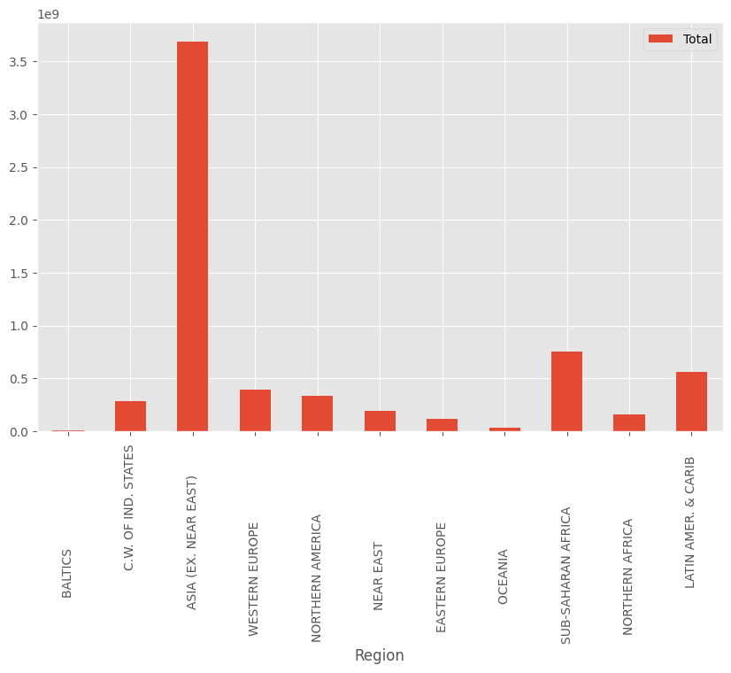

```python
pd_countries.plot(x='Region', y='Total',kind='bar', figsize=(10, 6))
```

## User defined functions for data manipulation

Our `countries` DataFrame has some problems:

- missing values
- some numbers use comma instead of point as floating point separator (e.g. Literacy = 99,4)

We can clean the data using User Defined Functions (UDF)

```python
from pyspark.sql.types import FloatType
from pyspark.sql.functions import udf
```

Define a Python function which coverts numbers with commas to `float`

```python
def to_float (s):
    if s is None:
            return None  # Return None if the value is None
    return float(s.replace(',', '.'))
```

Test that it works:

```python
to_float('0,99')
```

```
0.99
```

Now define a Spark UDF:

```python
float_udf = udf(to_float , FloatType())
```

Test it on a Data Frame

```python
literacy_countr = countries.withColumn("Literacy", float_udf("Literacy (%)"))
```

```python
literacy_countr
```

```
DataFrame[Country: string, Region: string, Population: int, Area (sq. mi.): int, Pop. Density (per sq. mi.): string, Coastline (coast/area ratio): string, Net migration: string, Infant mortality (per 1000 births): string, GDP ($ per capita): int, Literacy (%): string, Phones (per 1000): string, Arab…
```

OK, we can see that the `Literacy` is now `float`

```python
literacy_countr.where((col("Literacy") < 50) & (col("GDP ($ per capita)") > 700)).show()
```

```
+--------------+--------------------+----------+--------------+--------------------------+----------------------------+-------------+----------------------------------+------------------+------------+-----------------+----------+---------+---------+-------+---------+---------+-----------+--------+--…
|       Country|              Region|Population|Area (sq. mi.)|Pop. Density (per sq. mi.)|Coastline (coast/area ratio)|Net migration|Infant mortality (per 1000 births)|GDP ($ per capita)|Literacy (%)|Phones (per 1000)|Arable (%)|Crops (%)|Other (%)|Climate|Birthrate|Deathrate|Agriculture|Industry|Se…
+--------------+--------------------+----------+--------------+--------------------------+----------------------------+-------------+----------------------------------+------------------+------------+-----------------+----------+---------+---------+-------+---------+---------+-----------+--------+--…
|       Angola |SUB-SAHARAN AFRIC...|  12127071|       1246700|                       9,7|                        0,13|            0|                            191,19|              1900|        42,0|              7,8|      2,41|     0,24|    97,35|   null|    45,11|     24,2|      0,096|   0,658|  …
|   Bangladesh |ASIA (EX. NEAR EA...| 147365352|        144000|                    1023,4|                        0,40|        -0,71|                              62,6|              1900|        43,1|              7,3|     62,11|     3,07|    34,82|      2|     29,8|     8,27|      0,199|   0,198|  …
|        Benin |SUB-SAHARAN AFRIC...|   7862944|        112620|                      69,8|                        0,11|            0|                                85|              1100|        40,9|              9,7|     18,08|      2,4|    79,52|      2|    38,85|    12,22|      0,316|   0,138|  …
|       Bhutan |ASIA (EX. NEAR EA...|   2279723|         47000|                      48,5|                        0,00|            0|                            100,44|              1300|        42,2|             14,3|      3,09|     0,43|    96,48|      2|    33,65|     12,7|      0,258|   0,379|  …
| Burkina Faso |SUB-SAHARAN AFRIC...|  13902972|        274200|                      50,7|                        0,00|            0|                             97,57|              1100|        26,6|              7,0|     14,43|     0,19|    85,38|      2|    45,62|     15,6|      0,322|   0,196|  …
|         Chad |SUB-SAHARAN AFRIC...|   9944201|       1284000|                       7,7|                        0,00|        -0,11|                             93,82|              1200|        47,5|              1,3|      2,86|     0,02|    97,12|      2|    45,73|    16,38|      0,335|   0,259|  …
|  Gambia, The |SUB-SAHARAN AFRIC...|   1641564|         11300|                     145,3|                        0,71|         1,57|                             72,02|              1700|        40,1|             26,8|        25|      0,5|     74,5|      2|    39,37|    12,25|      0,308|   0,142|  …
|       Guinea |SUB-SAHARAN AFRIC...|   9690222|        245857|                      39,4|                        0,13|        -3,06|                             90,37|              2100|        35,9|              2,7|      3,63|     2,58|    93,79|      2|    41,76|    15,48|      0,237|   0,362|  …
|Guinea-Bissau |SUB-SAHARAN AFRIC...|   1442029|         36120|                      39,9|                        0,97|        -1,57|                            107,17|               800|        42,4|              7,4|     10,67|     8,82|    80,51|      2|    37,22|    16,53|       0,62|    0,12|  …
|         Iraq |NEAR EAST        ...|  26783383|        437072|                      61,3|                        0,01|            0|                             50,25|              1500|        40,4|             38,6|     13,15|     0,78|    86,07|      1|    31,98|     5,37|      0,073|   0,666|  …
|         Mali |SUB-SAHARAN AFRIC...|  11716829|       1240000|                       9,5|                        0,00|        -0,33|                            116,79|               900|        46,4|              6,4|      3,82|     0,03|    96,15|      2|    49,82|    16,89|       0,45|    0,17|  …
```

[output cut: 7 more lines]

- some rows have empty values!

```python
full_countries = countries.select('Country', 'Population', 'Literacy (%)', 'GDP ($ per capita)').na.drop()
```

We can now apply the new UDF to the Data Frame:

```python
full_countries = full_countries.withColumn("Literacy", float_udf("Literacy (%)"))
```

```python
full_countries.show(50)
```

```
+--------------------+----------+------------+------------------+--------+
|             Country|Population|Literacy (%)|GDP ($ per capita)|Literacy|
+--------------------+----------+------------+------------------+--------+
|        Afghanistan |  31056997|        36,0|               700|    36.0|
|            Albania |   3581655|        86,5|              4500|    86.5|
|            Algeria |  32930091|        70,0|              6000|    70.0|
|     American Samoa |     57794|        97,0|              8000|    97.0|
|            Andorra |     71201|       100,0|             19000|   100.0|
|             Angola |  12127071|        42,0|              1900|    42.0|
|           Anguilla |     13477|        95,0|              8600|    95.0|
|  Antigua & Barbuda |     69108|        89,0|             11000|    89.0|
|          Argentina |  39921833|        97,1|             11200|    97.1|
|            Armenia |   2976372|        98,6|              3500|    98.6|
|              Aruba |     71891|        97,0|             28000|    97.0|
|          Australia |  20264082|       100,0|             29000|   100.0|
|            Austria |   8192880|        98,0|             30000|    98.0|
|         Azerbaijan |   7961619|        97,0|              3400|    97.0|
|       Bahamas, The |    303770|        95,6|             16700|    95.6|
|            Bahrain |    698585|        89,1|             16900|    89.1|
|         Bangladesh | 147365352|        43,1|              1900|    43.1|
|           Barbados |    279912|        97,4|             15700|    97.4|
|            Belarus |  10293011|        99,6|              6100|    99.6|
|            Belgium |  10379067|        98,0|             29100|    98.0|
|             Belize |    287730|        94,1|              4900|    94.1|
|              Benin |   7862944|        40,9|              1100|    40.9|
|            Bermuda |     65773|        98,0|             36000|    98.0|
|             Bhutan |   2279723|        42,2|              1300|    42.2|
|            Bolivia |   8989046|        87,2|              2400|    87.2|
|           Botswana |   1639833|        79,8|              9000|    79.8|
|             Brazil | 188078227|        86,4|              7600|    86.4|
| British Virgin Is. |     23098|        97,8|             16000|    97.8|
|             Brunei |    379444|        93,9|             18600|    93.9|
|           Bulgaria |   7385367|        98,6|              7600|    98.6|
|       Burkina Faso |  13902972|        26,6|              1100|    26.6|
|              Burma |  47382633|        85,3|              1800|    85.3|
|            Burundi |   8090068|        51,6|               600|    51.6|
|           Cambodia |  13881427|        69,4|              1900|    69.4|
|           Cameroon |  17340702|        79,0|              1800|    79.0|
|             Canada |  33098932|        97,0|             29800|    97.0|
|         Cape Verde |    420979|        76,6|              1400|    76.6|
|     Cayman Islands |     45436|        98,0|             35000|    98.0|
|Central African R...|   4303356|        51,0|              1100|    51.0|
|               Chad |   9944201|        47,5|              1200|    47.5|
|              Chile |  16134219|        96,2|              9900|    96.2|
|              China |1313973713|        90,9|              5000|    90.9|
|           Colombia |  43593035|        92,5|              6300|    92.5|
|            Comoros |    690948|        56,5|               700|    56.5|
|   Congo, Dem. Rep. |  62660551|        65,5|               700|    65.5|
|Congo, Repub. of ...|   3702314|        83,8|               700|    83.8|
|       Cook Islands |     21388|        95,0|              5000|    95.0|
|         Costa Rica |   4075261|        96,0|              9100|    96.0|
|      Cote d'Ivoire |  17654843|        50,9|              1400|    50.9|
|            Croatia |   4494749|        98,5|             10600|    98.5|
+--------------------+----------+------------+------------------+--------+
only showing top 50 rows
```

```python
full_countries.where((col("Literacy") < 50) & (col("GDP ($ per capita)") > 700)).show()
```

```
+--------------+----------+------------+------------------+--------+
|       Country|Population|Literacy (%)|GDP ($ per capita)|Literacy|
+--------------+----------+------------+------------------+--------+
|       Angola |  12127071|        42,0|              1900|    42.0|
|   Bangladesh | 147365352|        43,1|              1900|    43.1|
|        Benin |   7862944|        40,9|              1100|    40.9|
|       Bhutan |   2279723|        42,2|              1300|    42.2|
| Burkina Faso |  13902972|        26,6|              1100|    26.6|
|         Chad |   9944201|        47,5|              1200|    47.5|
|  Gambia, The |   1641564|        40,1|              1700|    40.1|
|       Guinea |   9690222|        35,9|              2100|    35.9|
|Guinea-Bissau |   1442029|        42,4|               800|    42.4|
|         Iraq |  26783383|        40,4|              1500|    40.4|
|         Mali |  11716829|        46,4|               900|    46.4|
|   Mauritania |   3177388|        41,7|              1800|    41.7|
|   Mozambique |  19686505|        47,8|              1200|    47.8|
|        Nepal |  28287147|        45,2|              1400|    45.2|
|        Niger |  12525094|        17,6|               800|    17.6|
|     Pakistan | 165803560|        45,7|              2100|    45.7|
|      Senegal |  11987121|        40,2|              1600|    40.2|
+--------------+----------+------------+------------------+--------+
```

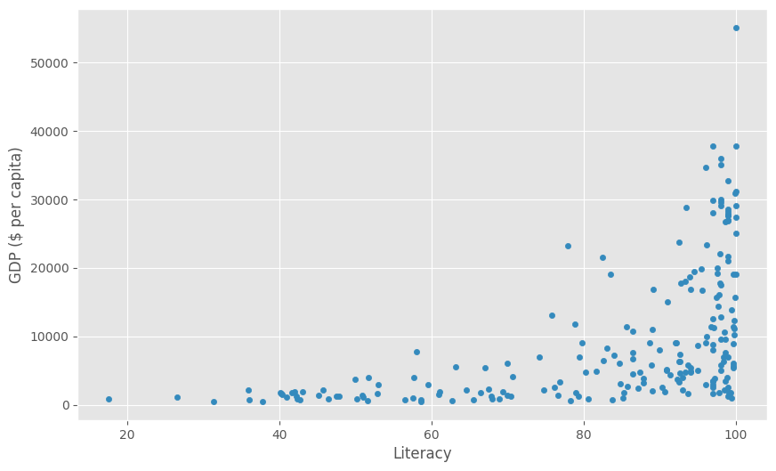

```python
full_countries.toPandas().plot(x="Literacy",y="GDP ($ per capita)",kind="scatter",figsize=(10, 6))
```

# Useful information

- https://spark.apache.org/docs/latest/quick-start.html
- https://spark.apache.org/docs/latest/sql-programming-guide.html
- https://pandas.pydata.org/pandas-docs/stable/visualization.html

# ASSIGNMENT

1. Narysuj wykres zależności kolumn Birthrate i Deathrate w zależności od GDP per capita dla 30 najbogatszych i 30 najbiedniejszych krajów.

```python
full_countries = countries.select('Country','Birthrate', 'Deathrate', 'GDP ($ per capita)').na.drop()
full_countries = full_countries.withColumn("Birthrate", float_udf("Birthrate"))
full_countries = full_countries.withColumn("Deathrate", float_udf("Deathrate"))
```

```python
top_30 = full_countries.sort(col("GDP ($ per capita)").desc()).limit(30)
bottom_30 = full_countries.sort(col("GDP ($ per capita)").asc()).limit(30)

top_30.show()
bottom_30.show()
```

```
+---------------+---------+---------+------------------+
|        Country|Birthrate|Deathrate|GDP ($ per capita)|
+---------------+---------+---------+------------------+
|    Luxembourg |    11.94|     8.41|             55100|
|        Norway |    11.46|      9.4|             37800|
| United States |    14.14|     8.26|             37800|
|       Bermuda |     11.4|     7.74|             36000|
|Cayman Islands |    12.74|     4.89|             35000|
|    San Marino |    10.02|     8.17|             34600|
|   Switzerland |     9.71|     8.49|             32700|
|       Denmark |    11.13|    10.36|             31100|
|       Iceland |    13.64|     6.72|             30900|
|       Austria |     8.74|     9.76|             30000|
|        Canada |    10.78|      7.8|             29800|
|       Ireland |    14.45|     7.82|             29600|
|       Belgium |    10.38|    10.27|             29100|
|     Australia |    12.14|     7.51|             29000|
|     Hong Kong |     7.29|     6.29|             28800|
|   Netherlands |     10.9|     8.68|             28600|
|         Japan |     9.37|     9.16|             28200|
|         Aruba |    11.03|     6.68|             28000|
|United Kingdom |    10.71|    10.13|             27700|
|        France |    11.99|     9.14|             27600|
+---------------+---------+---------+------------------+
only showing top 20 rows

+--------------------+---------+---------+------------------+
|             Country|Birthrate|Deathrate|GDP ($ per capita)|
+--------------------+---------+---------+------------------+
|         East Timor |    26.99|     6.24|               500|
|       Sierra Leone |    45.76|    23.03|               500|
|            Somalia |    45.13|    16.63|               500|
|            Burundi |    42.22|    13.46|               600|
|         Gaza Strip |    39.45|      3.8|               600|
|             Malawi |    43.13|    19.33|               600|
|           Tanzania |    37.71|    16.39|               600|
|        Afghanistan |     46.6|    20.34|               700|
|            Comoros |    36.93|      8.2|               700|
|   Congo, Dem. Rep. |    43.69|    13.27|               700|
|Congo, Repub. of ...|    42.57|    12.93|               700|
|            Eritrea |    34.33|      9.6|               700|
|           Ethiopia |    37.98|    14.86|               700|
|           Kiribati |    30.65|     8.26|               800|
|      Guinea-Bissau |    37.22|    16.53|               800|
|         Madagascar |    41.41|    11.11|               800|
|              Niger |    50.73|    20.91|               800|
|          West Bank |    31.67|     3.92|               800|
|              Yemen |    42.89|      8.3|               800|
|             Zambia |     41.0|    19.93|               800|
+--------------------+---------+---------+------------------+
only showing top 20 rows
```

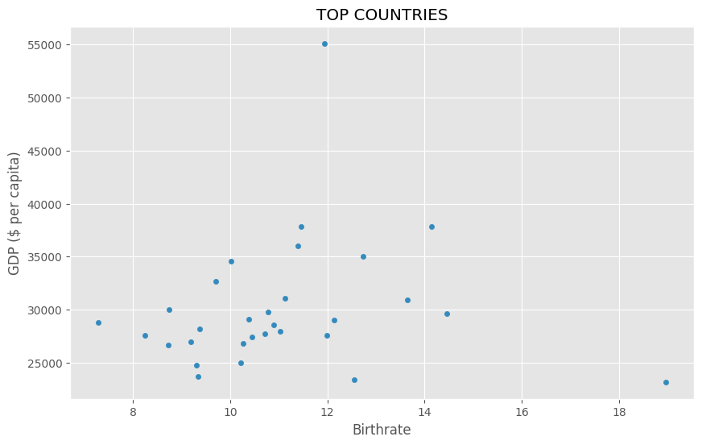

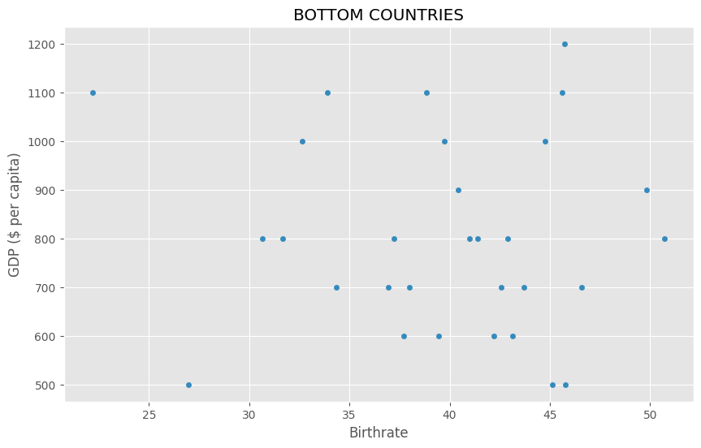

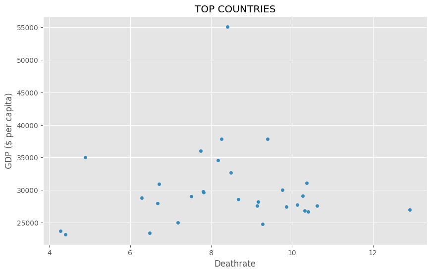

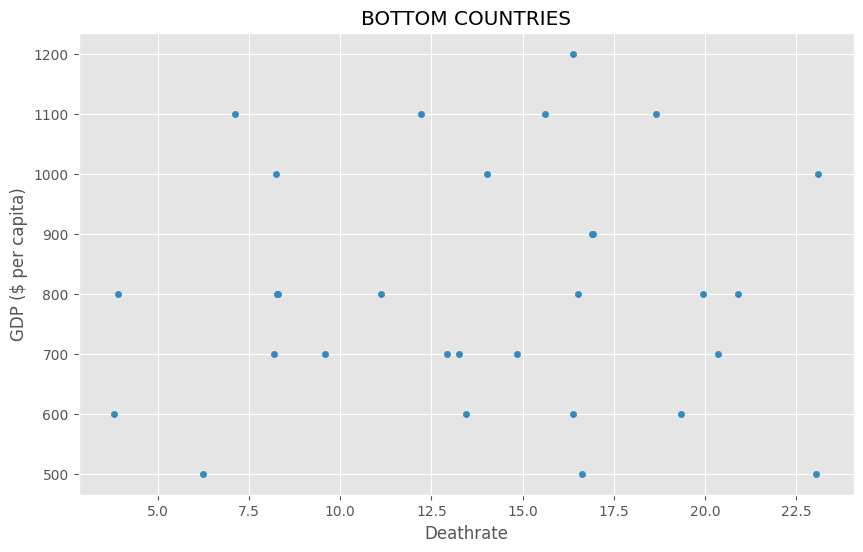

```python
top_30.toPandas().plot(x="Birthrate",y="GDP ($ per capita)",kind="scatter",figsize=(10, 6), title="TOP COUNTRIES")
bottom_30.toPandas().plot(x="Birthrate",y="GDP ($ per capita)",kind="scatter",figsize=(10, 6), title="BOTTOM COUNTRIES")

top_30.toPandas().plot(x="Deathrate",y="GDP ($ per capita)",kind="scatter",figsize=(10, 6), title="TOP COUNTRIES")
bottom_30.toPandas().plot(x="Deathrate",y="GDP ($ per capita)",kind="scatter",figsize=(10, 6), title="BOTTOM COUNTRIES")
```

2. Wczytaj zbiór danych "airports.csv" ze strony https://www.kaggle.com/jonatancr/airports (zawiera on dane na temat lotnisk z całego świata). Ponieważ w zbiorze tym nie ma nagłówka, nadaj własne nazwy kolumnom, korzystając z opisu pliku na stronie https://openflights.org/data.html. Narysuj na wykresie (mapie) położenia wszystkich/wybranych lotnisk.

```python
file_path = DATA_ROOT + "airports.csv"
"""Airport ID Unique OpenFlights identifier for this airport.
Name Name of airport. May or may not contain the City name.
City Main city served by airport. May be spelled differently from Name.
Country Country or territory where airport is located. See countries.dat to cross-reference to ISO 3166-1 codes.
IATA 3-letter IATA code. Null if not assigned/unknown.
ICAO 4-letter ICAO code.
Null if not assigned.
Latitude Decimal degrees, usually to six significant digits. Negative is South, positive is North.
Longitude Decimal degrees, usually to six significant digits. Negative is West, positive is East.
Altitude In feet.
Timezone Hours offset from UTC. Fractional hours are expressed as decimals, eg. India is 5.5.
DST Daylight savings time. One of E (Europe), A (US/Canada), S (South America), O (Australia), Z (New Zealand), N (None) or U (Unknown). See also: Help: Time
Tz database time zone Timezone in "tz" (Olson) format, eg. "America/Los_Angeles".
Type Type of the airport. Value "airport" for air terminals, "station" for train stations, "port" for ferry terminals and "unknown" if not known. In airports.csv, only type=airport is included.
Source Source of this data. "OurAirports" for data sourced from OurAirports, "Legacy" for old data not matched to OurAirports (mostly DAFIF), "User" for unverified user contributions. In airports.csv, only source=OurAirports is included.
The data is UTF-8 (Unicode) encoded.

Note: Rules for daylight savings time change from year to year and from country to country. The current data is an approximation for 2009, built on a country level. Most airports in DST-less regions in countries that generally observe DST (eg. AL, HI in the USA, NT, QL in Australia, parts of Canada) are marked incorrectly."""

# Read in the airports data
airports = spark.read.csv(file_path,header=False)
airports = airports.withColumnRenamed("_c0","Airport ID")\
                   .withColumnRenamed("_c1","Name")\
                   .withColumnRenamed("_c2","City")\
                   .withColumnRenamed("_c3","Country")\
                   .withColumnRenamed("_c4","IATA")\
                   .withColumnRenamed("_c5","ICAO")\
                   .withColumnRenamed("_c6","Latitude")\
                   .withColumnRenamed("_c7","Longitude")\
                   .withColumnRenamed("_c8","Altitude")\
                   .withColumnRenamed("_c9","Timezone")\
                   .withColumnRenamed("_c10","DST")\
                   .withColumnRenamed("_c11","Tz")\
                   .withColumnRenamed("_c12","Type")\
                   .withColumnRenamed("_c13","Source")

# Show the data
print(airports.show())
```

```
+----------+--------------------+--------------+----------------+----+----+------------------+-------------------+--------+--------+---+--------------------+-------+-----------+
|Airport ID|                Name|          City|         Country|IATA|ICAO|          Latitude|          Longitude|Altitude|Timezone|DST|                  Tz|   Type|     Source|
+----------+--------------------+--------------+----------------+----+----+------------------+-------------------+--------+--------+---+--------------------+-------+-----------+
|         1|      Goroka Airport|        Goroka|Papua New Guinea| GKA|AYGA|-6.081689834590001|      145.391998291|    5282|      10|  U|Pacific/Port_Moresby|airport|OurAirports|
|         2|      Madang Airport|        Madang|Papua New Guinea| MAG|AYMD|    -5.20707988739|      145.789001465|      20|      10|  U|Pacific/Port_Moresby|airport|OurAirports|
|         3|Mount Hagen Kagam...|   Mount Hagen|Papua New Guinea| HGU|AYMH|-5.826789855957031| 144.29600524902344|    5388|      10|  U|Pacific/Port_Moresby|airport|OurAirports|
|         4|      Nadzab Airport|        Nadzab|Papua New Guinea| LAE|AYNZ|         -6.569803|         146.725977|     239|      10|  U|Pacific/Port_Moresby|airport|OurAirports|
|         5|Port Moresby Jack...|  Port Moresby|Papua New Guinea| POM|AYPY|-9.443380355834961| 147.22000122070312|     146|      10|  U|Pacific/Port_Moresby|airport|OurAirports|
|         6|Wewak Internation...|         Wewak|Papua New Guinea| WWK|AYWK|    -3.58383011818|      143.669006348|      19|      10|  U|Pacific/Port_Moresby|airport|OurAirports|
|         7|  Narsarsuaq Airport|  Narssarssuaq|       Greenland| UAK|BGBW|     61.1604995728|     -45.4259986877|     112|      -3|  E|     America/Godthab|airport|OurAirports|
|         8|Godthaab / Nuuk A...|      Godthaab|       Greenland| GOH|BGGH|       64.19090271|     -51.6781005859|     283|      -3|  E|     America/Godthab|airport|OurAirports|
|         9|Kangerlussuaq Air...|   Sondrestrom|       Greenland| SFJ|BGSF|     67.0122218992|     -50.7116031647|     165|      -3|  E|     America/Godthab|airport|OurAirports|
|        10|      Thule Air Base|         Thule|       Greenland| THU|BGTL|     76.5311965942|     -68.7032012939|     251|      -4|  E|       America/Thule|airport|OurAirports|
|        11|    Akureyri Airport|      Akureyri|         Iceland| AEY|BIAR| 65.66000366210938| -18.07270050048828|       6|       0|  N|  Atlantic/Reykjavik|airport|OurAirports|
|        12| Egilsstaðir Airport|   Egilsstadir|         Iceland| EGS|BIEG|  65.2833023071289|-14.401399612426758|      76|       0|  N|  Atlantic/Reykjavik|airport|OurAirports|
|        13|Hornafjörður Airport|          Hofn|         Iceland| HFN|BIHN|         64.295601|           -15.2272|      24|       0|  N|  Atlantic/Reykjavik|airport|OurAirports|
|        14|     Húsavík Airport|       Husavik|         Iceland| HZK|BIHU|         65.952301|         -17.426001|      48|       0|  N|  Atlantic/Reykjavik|airport|OurAirports|
|        15|  Ísafjörður Airport|    Isafjordur|         Iceland| IFJ|BIIS| 66.05809783935547|-23.135299682617188|       8|       0|  N|  Atlantic/Reykjavik|airport|OurAirports|
|        16|Keflavik Internat...|      Keflavik|         Iceland| KEF|BIKF|   63.985000610352|   -22.605600357056|     171|       0|  N|  Atlantic/Reykjavik|airport|OurAirports|
|        17|Patreksfjörður Ai...|Patreksfjordur|         Iceland| PFJ|BIPA|         65.555801|            -23.965|      11|       0|  N|  Atlantic/Reykjavik|airport|OurAirports|
|        18|   Reykjavik Airport|     Reykjavik|         Iceland| RKV|BIRK|     64.1299972534|     -21.9405994415|      48|       0|  N|  Atlantic/Reykjavik|airport|OurAirports|
|        19|Siglufjörður Airport|  Siglufjordur|         Iceland| SIJ|BISI|         66.133301|           -18.9167|      10|       0|  N|  Atlantic/Reykjavik|airport|OurAirports|
|        20|Vestmannaeyjar Ai...|Vestmannaeyjar|         Iceland| VEY|BIVM| 63.42430114746094|-20.278900146484375|     326|       0|  N|  Atlantic/Reykjavik|airport|OurAirports|
+----------+--------------------+--------------+----------------+----+----+------------------+-------------------+--------+--------+---+--------------------+-------+-----------+
only showing top 20 rows

None
```

```python
locations_l = airports.select("Latitude", "Longitude").toPandas().values.tolist()
```

```python
import folium

# Create a world map
world_map = folium.Map(zoom_start=2)

# Add markers for each geolocation
for location in locations_l:
    folium.Marker(location).add_to(world_map)

# Save the map as an HTML file
world_map.save('ip_geolocation_map.html')

display(world_map)
```

[interactive chart not shown]

```python
airports.createOrReplaceTempView("airports")
```

```python
airports.printSchema()
airports = airports.withColumn("Altitude", airports["Altitude"].cast("float"))
airports.printSchema()
```

```
root
 |-- Airport ID: string (nullable = true)
 |-- Name: string (nullable = true)
 |-- City: string (nullable = true)
 |-- Country: string (nullable = true)
 |-- IATA: string (nullable = true)
 |-- ICAO: string (nullable = true)
 |-- Latitude: string (nullable = true)
 |-- Longitude: string (nullable = true)
 |-- Altitude: string (nullable = true)
 |-- Timezone: string (nullable = true)
 |-- DST: string (nullable = true)
 |-- Tz: string (nullable = true)
 |-- Type: string (nullable = true)
 |-- Source: string (nullable = true)

root
 |-- Airport ID: string (nullable = true)
 |-- Name: string (nullable = true)
 |-- City: string (nullable = true)
 |-- Country: string (nullable = true)
 |-- IATA: string (nullable = true)
 |-- ICAO: string (nullable = true)
 |-- Latitude: string (nullable = true)
 |-- Longitude: string (nullable = true)
 |-- Altitude: float (nullable = true)
 |-- Timezone: string (nullable = true)
 |-- DST: string (nullable = true)
 |-- Tz: string (nullable = true)
 |-- Type: string (nullable = true)
 |-- Source: string (nullable = true)
```

```python
import pyspark.sql.functions as F
```

```python
pd_airports = airports.select("Country", "Altitude")\
                      .groupBy("Country")\
                      .agg(F.min("Altitude").alias('Lowest airport'))\
                      .sort(col('Lowest airport').desc()).limit(10)
```

```python
pd_airports.show()
```

```
+-----------+--------------+
|    Country|Lowest airport|
+-----------+--------------+
|    Lesotho|        5105.0|
|     Rwanda|        4859.0|
|    Burundi|        2582.0|
|  West Bank|        2485.0|
|     Uganda|        2472.0|
|  Swaziland|        2075.0|
| Kyrgyzstan|        2058.0|
|   Botswana|        1772.0|
|     Malawi|        1580.0|
|South Sudan|        1513.0|
+-----------+--------------+
```

4. Na wykresie scatterplot narysuj zależność liczby lotnisk od powierzchni kraju.

Dane potrzebne do wykresu są w dwóch ramkach (Countries i Airports), konieczne więc będzie ich złączenie (join).

Nie zawsze nazwy tych samych krajów będą identyczne w obu ramkach, co może stanowić problem (złączenie nie powstanie). Zastanów się jak przy pomocy mechanizmu złączeń wykryć, które nazwy się różnią.

```python
print(countries)

print(airports)
```

```
DataFrame[Country: string, Region: string, Population: int, Area (sq. mi.): int, Pop. Density (per sq. mi.): string, Coastline (coast/area ratio): string, Net migration: string, Infant mortality (per 1000 births): string, GDP ($ per capita): int, Literacy (%): string, Phones (per 1000): string, Arab…
DataFrame[Airport ID: string, Name: string, City: string, Country: string, IATA: string, ICAO: string, Latitude: string, Longitude: string, Altitude: float, Timezone: string, DST: string, Tz: string, Type: string, Source: string]
```

```python
countries = countries.withColumnRenamed("Area (sq. mi.)","Area")
```

```python
countries.createOrReplaceTempView("countries")
airports.createOrReplaceTempView("airports")
merge_countries = countries.select("Country", 'Area')
merge_airports = airports.select("Country", "Airport ID")
```

```python
merge_airports = merge_airports.orderBy("Country")
merge_countries.join(merge_airports, merge_countries.Country == merge_airports.Country, "inner").show()
```

[output not shown]

```python
from pyspark.sql.types import StringType

merge_airports.show(20)
merge_countries.show(20)

#udf for stripping country names
def stripper(s):
    if s is None:
            return None  # Return None if the value is None
    return str.strip(s)

strip_udf = udf(stripper , StringType())
merge_countries = merge_countries.withColumn("Country", strip_udf("Country"))
merge_airports = merge_airports.withColumn("Country", strip_udf("Country"))
merge_countries.join(merge_airports, merge_countries.Country == merge_airports.Country, "inner").show()
```

```
+-----------+----------+
|    Country|Airport ID|
+-----------+----------+
|Afghanistan|     10057|
|Afghanistan|      2049|
|Afghanistan|      2050|
|Afghanistan|      2048|
|Afghanistan|      2052|
|Afghanistan|      2053|
|Afghanistan|      2054|
|Afghanistan|      2055|
|Afghanistan|      2051|
|Afghanistan|      5922|
|Afghanistan|      7036|
|Afghanistan|      7499|
|Afghanistan|      7500|
|Afghanistan|      7501|
|Afghanistan|      7868|
|Afghanistan|      8127|
|Afghanistan|      8146|
|Afghanistan|      8773|
|Afghanistan|      8825|
|Afghanistan|      2056|
+-----------+----------+
only showing top 20 rows

+------------------+-------+
|           Country|   Area|
+------------------+-------+
|      Afghanistan | 647500|
|          Albania |  28748|
|          Algeria |2381740|
|   American Samoa |    199|
|          Andorra |    468|
|           Angola |1246700|
|         Anguilla |    102|
|Antigua & Barbuda |    443|
|        Argentina |2766890|
|          Armenia |  29800|
|            Aruba |    193|
```

[output cut: 22 more lines]

```
|       Greenland|2166086|       Greenland|         8|
|       Greenland|2166086|       Greenland|         9|
|       Greenland|2166086|       Greenland|        10|
|         Iceland| 103000|         Iceland|        11|
|         Iceland| 103000|         Iceland|        12|
|         Iceland| 103000|         Iceland|        13|
|         Iceland| 103000|         Iceland|        14|
|         Iceland| 103000|         Iceland|        15|
|         Iceland| 103000|         Iceland|        16|
|         Iceland| 103000|         Iceland|        17|
|         Iceland| 103000|         Iceland|        18|
|         Iceland| 103000|         Iceland|        19|
|         Iceland| 103000|         Iceland|        20|
+----------------+-------+----------------+----------+
only showing top 20 rows
```

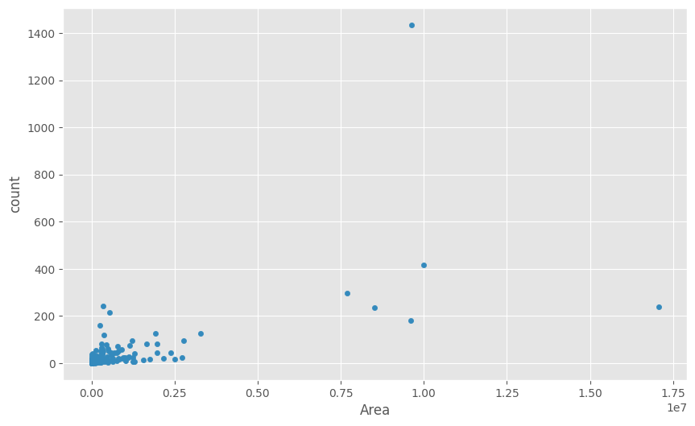

```python
merge_countries.join(merge_airports, merge_countries.Country == merge_airports.Country, "inner").select(merge_countries.Country, "Area").groupBy("Country", "Area").count().toPandas().plot(x="Area",y="count",kind="scatter",figsize=(10, 6))
```

5. Stwórz odpowiednią ramkę, która zawiera takie nazwy. Oblicz, ile lotnisk jest na poszczególnych kontynentach. To zadanie również wymaga złączenia ramek "Countries" i "Airports". Wynik przedstaw na wykresie kołowym.

```
+--------------------+-----+
|              Region|count|
+--------------------+-----+
|BALTICS          ...|   24|
|NORTHERN AFRICA  ...|  121|
|EASTERN EUROPE   ...|  143|
|NEAR EAST        ...|  208|
|C.W. OF IND. STATES |  357|
|SUB-SAHARAN AFRIC...|  534|
|OCEANIA          ...|  542|
|LATIN AMER. & CAR...|  921|
|ASIA (EX. NEAR EA...| 1064|
|WESTERN EUROPE   ...| 1224|
|NORTHERN AMERICA ...| 1875|
+--------------------+-----+
```

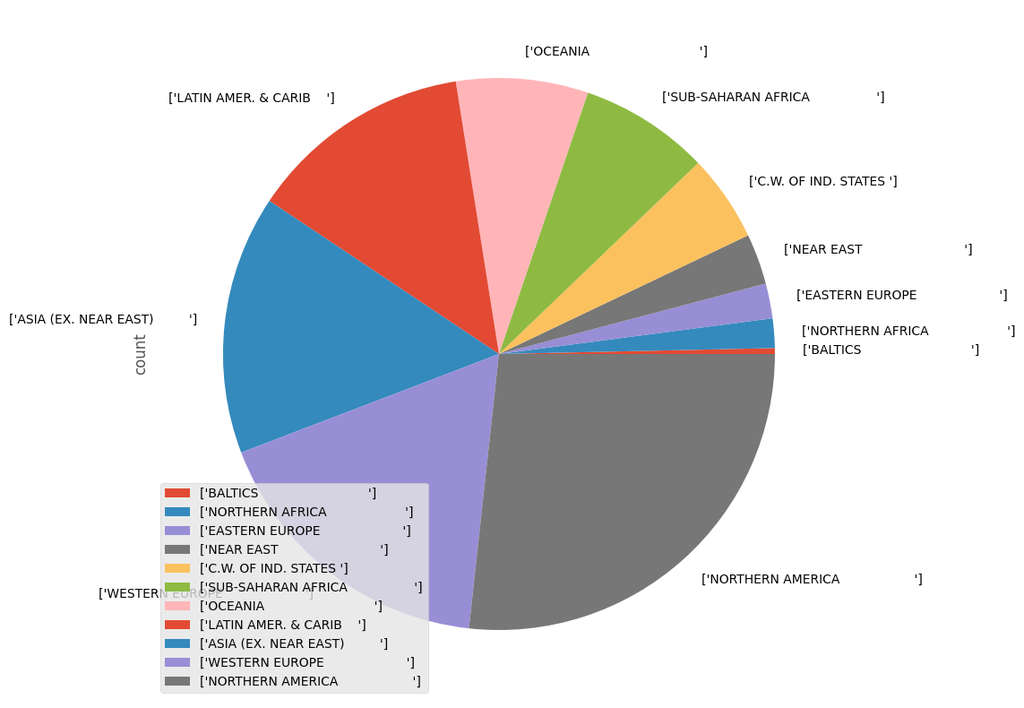

```python
merge_countries = countries.select("Country", 'Region')
merge_airports = airports.select("Country", "Airport ID")

merge_countries = merge_countries.withColumn("Country", strip_udf("Country"))
merge_airports = merge_airports.withColumn("Country", strip_udf("Country"))
data = merge_countries.join(merge_airports, merge_countries.Country == merge_airports.Country, "inner").select(merge_countries.Region).groupBy("Region").count().orderBy("count")
data.show()
regions = data.select("Region").toPandas().values.tolist()


data.toPandas().plot(x="Region",y="count",kind="pie",figsize=(18, 10), labels=regions)
```